# HW 3

SDS348 Fall 2020

September 18, 2020

## Arun Krishnaraj - ak37738

**This homework is due on Sep 20, 2020 at 11:59pm. Please submit as an HTML file on Canvas.**

*For all questions, include the R commands/functions that you used to find your answer. Answers without supporting code will not receive credit.*

#### Review of how to submit this assignment

> All homework assignments will be completed using R Markdown. These `.Rmd` files consist of >text/syntax (formatted using Markdown) alongside embedded R code. When you have completed the assignment (by adding R code inside codeblocks and supporting text outside of the codeblocks), create your document as follows:
> - Click the arrow next to the “Knit” button (above)
> - Choose “Knit to HTML”
> - Go to Files pane and put checkmark next to the correct HTML file
> - Click on the blue gear icon (“More”) and click Export
> - Download the file and then upload to Canvas

### Question 1:

##### 1.1 (1 pt) Assume diastolic blood pressure is normally distributed in a certain population, with a mean of 68 mmHg and a standard deviation 14 mmHg. What proportion of this population has a diastolic blood pressure less than 60 mmHg (i.e., what is the probability that a person in this population has a diastolic blood pressure less than 60)?

```r
pnorm(60, mean = 68, sd = 14)
```

```
## [1] 0.2838546
```

There’s a .284 probability that a person in this population has a diastolic blood pressure less than 60 mmHg.

##### 1.2 (1 pt) What diastolic blood pressure would put an individual from this population at the 95th percentile?

```r
qnorm(0.95, mean = 68, sd = 14)
```

```
## [1] 91.02795
```

A blood pressure of 91.028 mmHg would put an individual at the 95th percentile for diastolic blood pressure.

##### 1.3 (1 pt) What is the probability that a random individual from this population will have a diastolic blood pressure higher than 80? (Equivalently, what proportion of the population has a diastolic BP greater than 80 mmHg?)

```r
1 - pnorm(80, mean = 68, sd = 14)
```

```
## [1] 0.195683
```

There’s a .196 probability that a random individual from this population will have a diastolic blood pressure greater than 80 mmHg.

##### 1.4 (1 pt) What proportion of the population has a diastolic blood pressure bewteen 65 and 75?

```r
pnorm(75, mean = 68, sd = 14) - pnorm(65, mean = 68,
    sd = 14)
```

```
## [1] 0.2763003
```

.276 of the population has a diastolic blood pressure between 65 and 75 mmHg.

##### 1.5 (1 pt) Assume this distribution of diastolic blood pressure is for a healthy population. Say we observe someone (from an unknown population) with a diastolic BP of 88 mmHg. What’s the probability of observing someone with a diastolic BP this extreme (*in either direction of the mean*) in the healthy population (normal, mean of 68, standard deviation of 14). Think back to two-tailed tests from Biostats or the equivalent.

```r
2 * (1 - pnorm(88, mean = 68, sd = 14))
```

```
## [1] 0.1531275
```

There is a .153 probability of observing a diastolic BP this extreme; since we’re working with a normal distribution, we can find the probability of someone having a BP at least as large as 88 mmHg and double it to account for the other tail.

### Question 2

Now, set the seed to 348 with `set.seed()`. Then, with `rnorm` take a sample of size 10000 (ten thousand) from a normal distribution with a mean of 68 and a standard deviation of 14.

##### 2.1 (3 pts) Using mean() on a logical vector, what proportion of the total draws are less than 60? What proportion are greater than 80? What value in your sample represents the 95th percentile?

```r
set.seed(348)
samp <- rnorm(10000, mean = 68, sd = 14)
mean(samp < 60)
```

```
## [1] 0.2973
```

```r
mean(samp > 80)
```

```
## [1] 0.1925
```

```r
quantile(samp, 0.95)
```

```
##      95%
## 91.14229
```

There is a .2973 proportion of total draws that are less than 60; there is a .1925 proportion greater than 80. The 95th percentile of this sample set is 91.14229.

##### 2.2 (2 pts) What proportion of your sample is between 65 and 75? What proportion is less than 48 *and* greater than 88?

```r
mean(samp > 65 & samp < 75)
```

```
## [1] 0.267
```

```r
mean(samp < 48 & samp > 88)
```

```
## [1] 0
```

There is a .267 proportion of total draws that are between 65 and 75; the proportion of the sample that is both less than 48 and greater than 88 is 0.

##### 2.3 (1 pts) Why are your answers to question 2 close to those in question 1? Why are they not exactly the same?

Since we’re using simulation to build the distribution, we know that as the number of simulations increases we get a closer approximation to the distribution itself; as a result of the Law of Large Numbers, we should expect there to be a decreasing difference between the sample average and true distribution as the sample size increases.

##### 2.4 (4 pts) Make your sample from question 2 into a dataframe and, using ggplot2, make a histogram of the sample by mapping the sample to the x-axis in the main `ggplot()` function and then adding `geom_histogram(aes(y=..density..))`. Then, overlay an density plot with `geom_density()`. Using `geom_vline(xintercept=)`, add solid vertical lines corresponding to the 2.5th and the 97.5th percentile of the sample (i.e., using `quantile`). Next overlay a normal distribution with a mean of 68 and a standard deviation of 14 using `geom_line()` with `dnorm()` and `stat="function"`. Make it a different color to differentiate it from the empirical/sample density. Finally, using `geom_vline(xintercept=)`, add dashed vertical lines of the same new color corresponding to the 2.5th and the 97.5th percentile of the actual normal distribution (the healthy population; i.e., using `qnorm`).

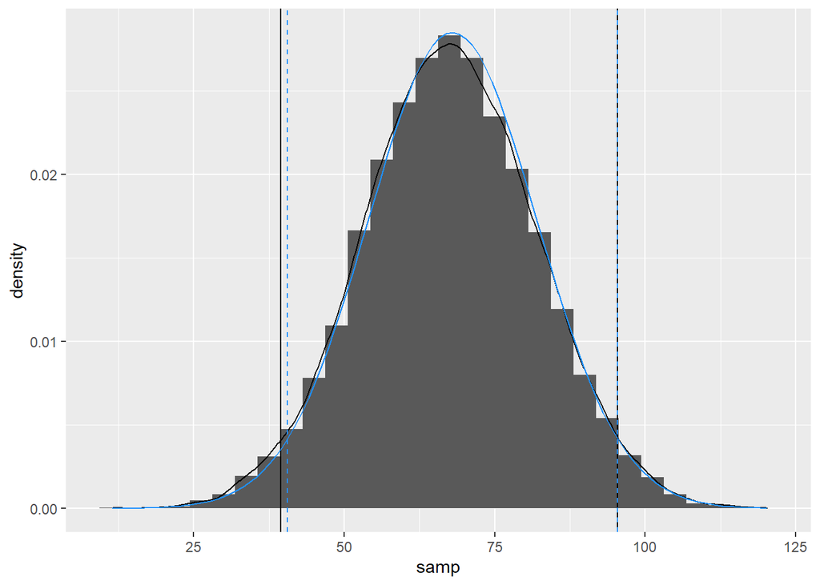

```r
library(ggplot2)
df <- data.frame(samp)  #makes your sample a column of a dataframe called df
ggplot(df, aes(x = samp)) + geom_histogram(aes(y = ..density..)) +
    geom_density() + geom_vline(xintercept = quantile(df$samp,
    0.025)) + geom_vline(xintercept = quantile(df$samp,
    0.975)) + stat_function(geom = "line", fun = dnorm,
    args = list(mean = 68, sd = 14), color = "dodgerblue") +
    geom_vline(xintercept = qnorm(0.025, mean = 68,
        sd = 14), color = "dodgerblue", linetype = "dashed") +
    geom_vline(xintercept = qnorm(0.975, mean = 68,
        sd = 14), color = "dodgerblue", linetype = "dashed")
```

### Question 3

##### 3.1 (2 pt) Using `dplyr` functions (filter, summarize; do not use any [] or $) and the `quakes` dataset, What is the mean of the variable `mag` when `depth` is *greater than* the median depth? What is the mean of the variable `mag` when `depth` is *less than* the median depth?

```r
library(dplyr)
quakes %>% filter(depth > median(depth)) %>% summarize(mean(mag))
```

```
##   mean(mag)
## 1    4.5232
```

```r
quakes %>% filter(depth < median(depth)) %>% summarize(mean(mag))
```

```
##   mean(mag)
## 1    4.7176
```

The mean of `mag` is 4.52 when `depth` is greater than the median depth, and 4.72 when `depth` is less than the median depth.

##### 3.2 (1 pt) Using `dplyr` and the `quakes` dataset, create a new variable called `depth_m` that gives `depth` in meters rather than kilometers. Use `mutate()` *only once* to achieve this! Do not use any [] or $.

```r
quakes <- quakes %>% mutate(depth_m = depth * 1000)  #assigned to new variable to suppress print
```

##### 3.3 (1 pt) Finally, using ggplot, take the quakes dataset and make a scatterplot of `long` (x-axis) and `lat` (y-axis) and color the points by `depth`. Add `coord_map()` to scale axes with mercator projection (if this doesn’t work, use coord_fixed to make x- and y-axis scales the same). Optionally, add the extra code below to overlay world map data for this region using the code provided below.

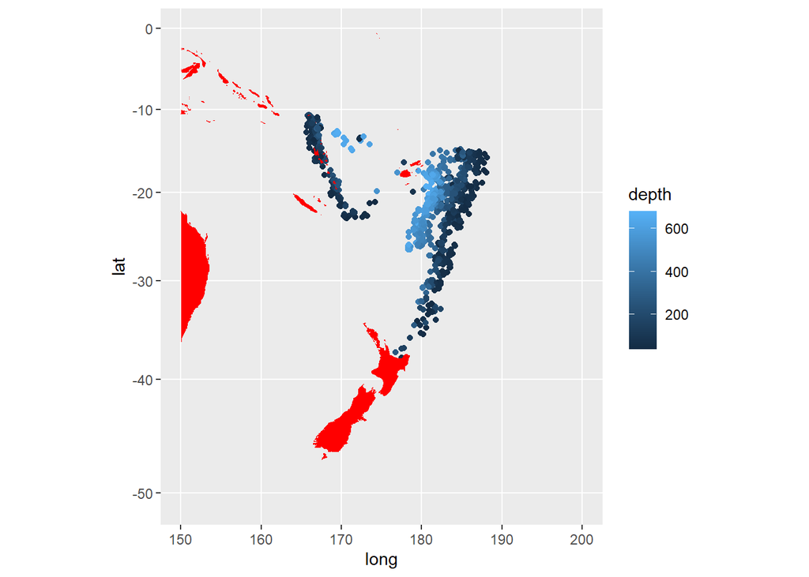

[output not shown]

[output not shown]

```r
library(maps)  #install.packages('maps') if not on the servers
world <- map_data("world")

ggplot(quakes, aes(x = long, y = lat)) + geom_point(aes(color = depth)) +
    coord_map() + geom_polygon(aes(long, lat, group = group),
    data = world, fill = "red") + xlim(150, 200) +
    ylim(-50, 0)
```